# Short Paper

Irina Vélez

Otto Palkama

2023-10-30

Abstract

[output not shown]

# 1. Introduction

The idea is to explore how the use of Large Language Models (LLMs) as General Purpose Technology (GPT) could reshape industries, considering the generalization capabilities of LLMs and the rapid adoption of these tools by the public and firms.

A. Background on the potential economic impact of Large Language Models (LLMs) as General Purpose Technology (GPT) B. Objective of the paper: Exploring how the use of LLMs as GPT could reshape industries and contribute to economic growth

Generalization of tools seems to be an important characteristic to leverage the potential of growth and development, because if a same tool could be broad use for different purposes, so the tool becomes in a very valuable tool.

Until now the abilities reached by the Large Languages Models LLMs have arisen to a certain level of computational power that might require scaling up past this threshold (10^23 training FLOPs), meaning that they are able to perform multiple tasks related to Text Understanding and Generation,Problem Solving and Mathematics, Image and Data Classification, Text Analysis and Comprehension, and so on, but as [@weiemergent] suggested for future works, it could be possible new abilities could emerge scaling up the models and understanding how emergence occurs would provide new insights into how to train more-capable language models.

On the other hand, the use of LLMs as a base technology of other tools, such as software-AI powered, open a new window and enveloped the potential of productivity improvements of the work-human force or human capital as it was mention by [@gptaregpts] telling that LLMs such as GPTs exhibit traits of general-purpose technologies, could have considerable economic, social, and policy implications.

So, the potential arising of emergent abilities and the wide use of LLMs as enablers of new tools (AI based-software) alongside the spread use of tools such as ChatGPT by a large amount of humans (here: million of users of chatGPT), it could signify a future unseen before by the human beings, because the expansion and pushing of new boarders and limits would be accelerated.

# Generalization Capabilities of LLMs as GPT

A. Examining the adoption rate of previous GPTs B. Key factors contributing to the widespread adoption of a technology as a GPT C. Reviewing the literature on the potential of AI as a GPT

Artificial intelligence a term coined by emeritus Stanford Professor John McCarthy in 1955, was defined by him as “the science and engineering of making intelligent machines”.[^1] These systems are designed to simulate human cognitive abilities, such as learning, reasoning, problem-solving, perception, and language understanding. Within the realm of AI, Large Language Models (LLMs) are a specific type of AI model that utilizes deep learning techniques, particularly neural networks, to process and generate human-like language. LLMs are trained on vast amounts of text data and can perform tasks like language translation, text summarization, and question answering.

In the past, computer programs were developed by painstakingly encoding human knowledge, following a precise set of instructions that mapped specific inputs to desired outputs. This approach required programmers to meticulously define every step of the process. However, machine learning systems operate differently. They utilize general algorithms, such as neural networks, which enable them to independently determine the appropriate mapping between inputs and outputs. This is achieved through exposure to extensive datasets containing numerous examples. By analyzing and learning from these examples, machine learning systems can identify patterns and make accurate predictions or classifications without explicit programming instructions.

General Purpose Technology is a transformative technology with a strong improvement process at the begining and eventually becoming widely adopted for its multiples uses, while producing many spillover effects [@paradox]. As such, it have a pervasive impact on society as a whole, mainly due to its capability to redefine the ways in which businesses operate, improve productive and contribute to long-term economic growth. Some well-know examples are steam power, electricity, semiconductors, and internet.

# Assessing the Potential Economic Impact

Considering the potential of the AI as a new GPT, specifically the LLMs, assessing its potential economic impact to setting expectatives, it could be address based on a retrospective approach what it means that the behaviour of previous General Purpose Technology like internet, electricity or semiconductors, can give a more realistic answer to this question, given the current conditions of uncertainty of this time.

The positive expectations regarding how new technologies could drive development, economic growth, and generate substantial profits are often accompanied by the optimistic mindset of industrial and well-known technology leaders, as well as venture capitalists. Simultaneously, the financial sector capitalizes on this excitement through speculative investments and forecasts of future company wealth. As mentioned by [@paradox], “there is no inherent inconsistency between forward-looking technological optimism and backward-looking disappointment. Both can simultaneously exist,” especially during periods of transformative changes.

Indeed, this question have already answered by [@paradox] 5 years before the launch of chatGPB by OpenAI. [@paradox] highlight a similar AI phenomenon such as its predecesors GPTs which it is outlined in a context of uncertainty times or structural changes, as well as a misalignment between the optimistic expectations of investors versus the discouraging results registered in the statistics. This apparently non-congruence rely on the time lag between invention and their full impact on the economy and society, because it takes time to build the stock of the new technology, develop the new human capital skillset, the re-engineering process of business process transformations and develop complementary innovations necessary for its full realization.

One example mentioned by [@paradox] is callcenters, stating that there was 2.2 million of agents working in the callcenter’s industry in the United States and it was plausible at that time that the voice recognition system such as IBM’s Watson could reduce the number of workers by 60%. As now is easy to answer this question with the backmirror, it’s evident that the expectations have not been meet.

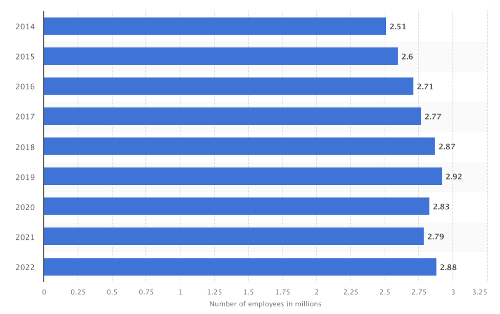

[figure not shown]

B. Evaluating the potential economic impact in terms of value creation and cost optimization 1. Real cases of successful implementations of LLMs for value creation 2. Real cases of successful implementations of LLMs for cost optimization

[output not shown]

Taking into consideration the conclusion made by [@paradox] about the emergence contradiction that positive and hope expectations of investors and the discourage view of growth in the statistics, in times of structural changes or rapid changes is genuiny, and is mainly explained by the lag between the the innovation take place at the first place and the time required to see the full realised benefits as welfare for society.

Above, it could explain too by the intrinsencal characteristic of human beings who want see their expectations become true during their lifetime, time that could not be enought to reflect the total benefit and at the same time the slow pace of human being’s ability to incorporate or assimilate the completely benefits of the new technology.

So, it is reasonable think that the impact that AI could have in the society don’t be different from the previous results of GPTs implementations.

So, now making an update to the work made by [@paradox] in 2017, in retrospective his insights seem still valid, because still it could be too early to assess the real economic impact.

Total Factor Productivity should reflect the exceptional technological advance

Review data: CBInsights - Labour Productivity Growth vs Global Investment focused on AI - OECD Productivity Growth - Real Median income has stagnated since the late 1990s

Both capital deepening and total factor productivity (TFP) growth lead to labor productivity growth, and both seem to be playing a role in the slowdown

The old adage that “past performance is not predictive of future results” applies well to trying to predict productivity growth in the years to come, especially in periods of a decade or longer. Historical stagnation does not justify forward-looking pessimism. Taken from Paradox

C. Intangible capital - capital may not be reflected in the measurements of economic growth

AI developing skills: Perception and cognition

# LLMs vs. Artificial General Intelligence (AGI)

A. Understanding the difference between LLMs and AGI B. Exploring whether AGI is the real General Purpose Technology

# Acknowledging Benefits and Limitations of LLMs as GPT

A. Discussing the potential benefits of LLMs as GPT B. Addressing the limitations and challenges associated with LLMs as GPT

# Conclusion

A. Summarizing the main points discussed in the paper B. Emphasizing the potential of LLMs as GPT in reshaping industries

# Bibliography styles

Here are two sample references: @Feynman1963118 [@Dirac1953888].

By default, natbib will be used with the `authoryear` style, set in `classoption` variable in YAML. You can sets extra options with `natbiboptions` variable in YAML header. Example

```yaml
natbiboptions: longnamesfirst,angle,semicolon
```

There are various more specific bibliography styles available at https://support.stmdocs.in/wiki/index.php?title=Model-wise_bibliographic_style_files. To use one of these, add it in the header using, for example, `biblio-style: model1-num-names`.

## Using CSL

If `citation_package` is set to `default` in `elsevier_article()`, then pandoc is used for citations instead of `natbib`. In this case, the `csl` option is used to format the references. Alternative `csl` files are available from https://www.zotero.org/styles?q=elsevier. These can be downloaded and stored locally, or the url can be used as in the example header.

# Equations

Here is an equation:
$$f_{X}(x) = \left(\frac{\alpha}{\beta}\right)
\left(\frac{x}{\beta}\right)^{\alpha-1}
e^{-\left(\frac{x}{\beta}\right)^{\alpha}};
\alpha,\beta,x > 0 .$$

Here is another:
$$\begin{align}
a^2+b^2=c^2.
\end{align}$$

Inline equations: $\sum_{i = 2}^\infty\{\alpha_i^\beta\}$

# Figures and tables

[figure not shown]

A meaningless scatterplot.

# Tables coming from R

```r
knitr::kable(head(mtcars)[,1:4],
    caption = "\\label{tab1}Caption centered above table"
)
```

Caption centered above table

|  | mpg | cyl | disp | hp |
| --- | --- | --- | --- | --- |
| Mazda RX4 | 21.0 | 6 | 160 | 110 |
| Mazda RX4 Wag | 21.0 | 6 | 160 | 110 |
| Datsun 710 | 22.8 | 4 | 108 | 93 |
| Hornet 4 Drive | 21.4 | 6 | 258 | 110 |
| Hornet Sportabout | 18.7 | 8 | 360 | 175 |
| Valiant | 18.1 | 6 | 225 | 105 |

# References

[^1]: Available at: https://hai.stanford.edu/sites/default/files/2020-09/AI-Definitions-HAI.pdf